# Analysis of severe weather events health and economic impacts

# Results

## Storm events population health impact

To clarify what is the population health impact of the storm events, we first summarize the fatalities and injuries per event type:

```r
library(plyr)
health_impact <- ddply(health_dat, "EVTYPE", summarize, total_death=sum(FATALITIES), total_injuries=sum(INJURIES))
```

From this health_impact dataset, we can extract the event types producing the highest number of fatalities and injuries. But first, to simplify the analysis, we can turn the total number of death and injuries into percentages:

```r
tot_death <- sum(health_impact$total_death)
tot_inj <- sum(health_impact$total_injuries)

health_impact <- mutate(health_impact, total_death = 100.0*total_death/tot_death, total_injuries = 100.0*total_injuries/tot_inj)

# select the highest fatalities values:
highest_death <- health_impact[order(health_impact$total_death, decreasing=T),]
highest_inj <- health_impact[order(health_impact$total_injuries, decreasing=T),]
```

Also note here that those storm event were responsible so far for at least 15145 deaths and 140528 injuries according to this report.

Now to get an idea on the most harmful type of storm event we will mainly consider those responsible for 80% of the fatalities and injuries respectively:

```r
# Accumulate the percentage of death and injuries:
highest_death <- mutate(highest_death,accum_death=cumsum(total_death))
highest_inj <- mutate(highest_inj,accum_injuries=cumsum(total_injuries))

focus_death <- highest_death[highest_death$accum_death<80.0,]
focus_inj <- highest_inj[highest_inj$accum_injuries<80.0,]

# Compute the number of event types of interest:
nfdeath <- dim(focus_death)[1]
nfinj <- dim(focus_inj)[1]
```

Finally we can plot here the distribution of the 10 most deadly storm event types and the 4 types responsible for about 80% of the injuries:

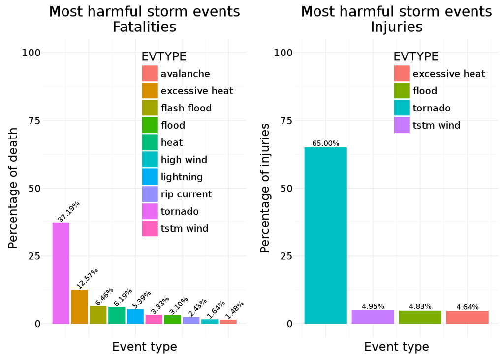

```r
library(ggplot2)
library(gridExtra)
p<-ggplot(focus_death, aes(x=1:nfdeath, y=total_death, fill=EVTYPE)) + geom_bar(stat="identity")+theme_minimal()
p<-p+labs(title="Most harmful storm events\nFatalities", x="Event type", y = "Percentage of death")
p<-p+geom_text(aes(label=sprintf("%.2f%%",total_death)), vjust=0.0, size=2.5, angle=45, hjust=0.0)
p<-p+theme(legend.justification=c(1,1), legend.position=c(1,1), axis.text.x=element_blank())
p<-p+scale_y_continuous(limits = c(0.0,100.0))

p2<-ggplot(focus_inj, aes(x=1:nfinj, y=total_injuries, fill=EVTYPE)) + geom_bar(stat="identity")+theme_minimal()
p2<-p2+labs(title="Most harmful storm events\nInjuries", x="Event type", y = "Percentage of injuries")
p2<-p2+geom_text(aes(label=sprintf("%.2f%%",total_injuries)), vjust=-0.3, size=2.5)
p2<-p2+theme(legend.justification=c(1,1), legend.position=c(1,1), axis.text.x=element_blank())
p2<-p2+scale_y_continuous(limits = c(0.0,100.0))

grid.arrange(p,p2,ncol=2)
```

As represented on the graphics above it seems that tornados are the absolute most harmful storm events during the period covered by the source dataset. The fatalities impact is then more distributed on about 10 event types, whereas, for the injuries, we can select only 4 event types responsible for most injury cases (80%).

## Storm events economic impact

We start here with summarizing the property and crop damage per event type:

```r
library(plyr)
eco_impact <- ddply(eco_dat, "EVTYPE", summarize, prop_damage=sum(PROPDMG), crop_damage=sum(CROPDMG))

eco_nevents <- dim(eco_impact)[1]
```

We now have to select the most harmful event types amongt the 861 unique event types found. To acheive this we can proceed as with the population health analysis: we turn the numbers of interest into percentages, and we select the event types responsible for about 80% of the damage costs.

But this time, we will summarise the input data one step further, and assume that property damages and crop damages have equivalent economic impact, so we can sum them together first.

```r
# compute the total damages:
eco_impact$total_damage <- eco_impact$prop_damage + eco_impact$crop_damage

# compute the overall total damage value:
tot_dmgvalue <- sum(eco_impact$total_damage)

# turn the total damage into percentages:
eco_impact$total_damage <- 100.0*eco_impact$total_damage/tot_dmgvalue

# order the entries by total damage percentage values, and only keep the EVTYPE
# and the total_damage columns in this process:
eco_impact <- eco_impact[order(eco_impact$total_damage, decreasing = T),c("EVTYPE","total_damage")]

# Now add the cumulative damage percentage column:
eco_impact <- mutate(eco_impact, accum_damage = cumsum(total_damage))

# Lets print the 20 first entries:
head(eco_impact,10)
```

```
##                    EVTYPE total_damage accum_damage
## 146                 flood    31.551737     31.55174
## 342 hurricane and typhoon    15.094514     46.64625
## 722               tornado    12.038070     58.68432
## 566           storm surge     9.093506     67.77783
## 201                  hail     3.937305     71.71513
## 131           flash flood     3.686353     75.40149
## 76                drought     3.152383     78.55387
## 341             hurricane     3.066652     81.62052
## 503           river flood     2.130126     83.75065
## 366             ice storm     1.882160     85.63281
```

We can now produce a plot presenting the event types responsible for about 80% of the damage costs.

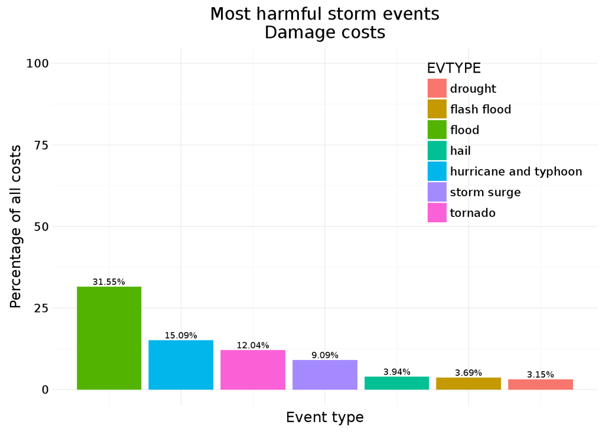

```r
# keep only the most damaging event types:
eco_focus <- eco_impact[eco_impact$accum_damage<80.0,]

# keep number of focused event types:
eco_nevents <- dim(eco_focus)[1]

# Generate the bar plot:
library(ggplot2)

p<-ggplot(eco_focus, aes(x=1:eco_nevents, y=total_damage, fill=EVTYPE)) + geom_bar(stat="identity")+theme_minimal()
p<-p+labs(title="Most harmful storm events\nDamage costs", x="Event type", y = "Percentage of all costs")
p<-p+geom_text(aes(label=sprintf("%.2f%%",total_damage)), vjust=-0.3, size=2.5, angle=0, hjust=0.5)
p<-p+theme(legend.justification=c(1,1), legend.position=c(1,1), axis.text.x=element_blank())
p<-p+scale_y_continuous(limits = c(0.0,100.0))

p
```

We observe from the previous graph that 7 event types are responsible for about 80% of the damage costs. Among those listed weather events we can notice that the **floods**,**hurricanes** and **typhoon** are the most severe followed once again by the **tornados**.

## Storm events impact evolution

```r
# we start with extracting the year from the event begin date:
dates <- as.Date(data$BGN_DATE,format="%m/%d/%Y %H:%M:%S")
data$years <- as.numeric(format(dates,'%Y'))

# keep only the variables of interest:
evol_dat <- select(data, EVTYPE,FATALITIES,INJURIES,PROPDMG,CROPDMG,PROPDMGEXP,CROPDMGEXP,years)

evol_dat$PROPDMGEXP <- fixMultiplier(evol_dat$PROPDMGEXP)
evol_dat$CROPDMGEXP <- fixMultiplier(evol_dat$CROPDMGEXP)

# Now perform the damage cost multiplications:
evol_dat <- mutate(evol_dat, PROPDMG=as.numeric(PROPDMG)*PROPDMGEXP,CROPDMG=as.numeric(CROPDMG)*CROPDMGEXP )

# drop the multipliers:
evol_dat <- select(evol_dat, EVTYPE,FATALITIES,INJURIES,PROPDMG,CROPDMG,years)

# Now clean the EVTYPE:
evol_dat$EVTYPE <- gsub("\\.","",evol_dat$EVTYPE)
evol_dat$EVTYPE <- gsub("/$","",evol_dat$EVTYPE)
evol_dat$EVTYPE <- gsub("/"," AND ",evol_dat$EVTYPE)
evol_dat$EVTYPE <- gsub(" & "," AND ",evol_dat$EVTYPE)
evol_dat$EVTYPE <- tolower(evol_dat$EVTYPE)

# We now summarize the data per year and per event type:
# note that this time we merge the fatalalities and injuries to simplify this analysis:
library(plyr)
evol_impact <- ddply(evol_dat, c("years","EVTYPE"), summarize, health_cost=sum(FATALITIES+INJURIES), eco_cost=sum(PROPDMG+CROPDMG))

#head(evol_impact, 20)

# also summarize the data per year to get the percentage values:
impact_year <- ddply(evol_dat, c("years"), summarize, total_health_cost=sum(FATALITIES+INJURIES), total_eco_cost=sum(PROPDMG+CROPDMG))

#head(impact_year, 20)

# merge this year sum back into the eco_impact:
evol_impact <- merge(evol_impact, impact_year, by="years")
#head(evol_impact,20)

# Now compute the percentage of health and damage costs for each event type and each year:
evol_impact <- mutate(evol_impact, health_cost = 100.0*health_cost/total_health_cost, eco_cost=100.0*eco_cost/total_eco_cost)
#head(evol_impact)
```

Now we may postulate that the data collected during the last years is the most accurate, and as such, we might want to consider the most harmful event types from those latest years only, and see how their history evolved. Here we select the 5 top event types from the last year of the input dataset (eg. 2011):

```r
#selecting the most harmful events from the latest year only:
lasty_dat<- evol_impact[evol_impact$years==2011,]

# Select the most harmful event types:
heal_lasty_dat <- lasty_dat[order(lasty_dat$health_cost, decreasing=T),]
eco_lasty_dat <- lasty_dat[order(lasty_dat$eco_cost, decreasing =T),]

heal_lasty_dat <- mutate(heal_lasty_dat,accum_cost = cumsum(health_cost))
eco_lasty_dat <- mutate(eco_lasty_dat,accum_cost = cumsum(eco_cost))

heal_lasty_dat <- heal_lasty_dat[1:5,c("years","EVTYPE","health_cost")]
eco_lasty_dat <- eco_lasty_dat[1:5,c("years","EVTYPE","eco_cost")]

heal_lasty_dat
```

```
##      years            EVTYPE health_cost
## 2223  2011           tornado   76.756880
## 2202  2011              heat    7.664317
## 2222  2011 thunderstorm wind    4.855583
## 2212  2011         lightning    2.501706
## 2194  2011    excessive heat    1.978622
```

```r
eco_lasty_dat
```

```
##      years      EVTYPE  eco_cost
## 2223  2011     tornado 45.699981
## 2197  2011       flood 36.521851
## 2196  2011 flash flood  6.831094
## 2227  2011    wildfire  3.053089
## 2201  2011        hail  2.475739
```

Now we can plot the history of the 5 most harmful event type selected in 2011:

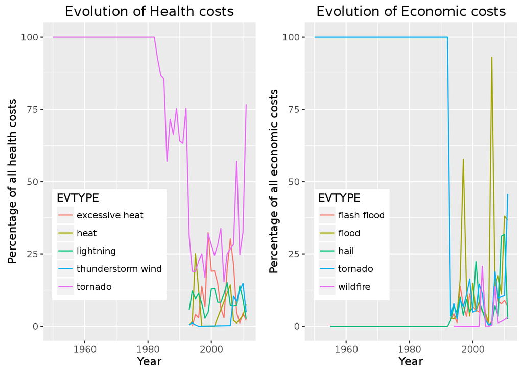

```r
# select only the event types of interest:
heal_impact <- evol_impact[evol_impact$EVTYPE %in% heal_lasty_dat$EVTYPE,]
eco_impact <- evol_impact[evol_impact$EVTYPE %in% eco_lasty_dat$EVTYPE,]

p <- ggplot(data=heal_impact, aes(x=years, y=health_cost, group=EVTYPE, color=EVTYPE)) + geom_line()
p<-p+labs(title="Evolution of Health costs", x="Year", y = "Percentage of all health costs")
p<-p+theme(legend.justification=c(0,0), legend.position=c(0,0.1))

p2 <- ggplot(data=eco_impact, aes(x=years, y=eco_cost, group=EVTYPE, color=EVTYPE)) + geom_line()
p2<-p2+labs(title="Evolution of Economic costs", x="Year", y = "Percentage of all economic costs")
p2<-p2+theme(legend.justification=c(0,0), legend.position=c(0,0.1))

grid.arrange(p,p2,ncol=2)
```

Further analysis would be required here to clarify what are the most significant weather events disregarding the early years in the input dataset.